### Get and Clean the Data

Get the data in clean, standard format for further analysis Different type of analysis require different format. Mainly, we need to get the following:

1. Corpus of text
2. Document Term Matrix

Specifically, we'll be walking through:

1. **Getting the data -** in this case, we have our dataset from Kaggle
2. **Cleaning the data -** we will walk through popular text pre-processing techniques
3. **Organizing the data -** we will organize the cleaned data into a way that is easy to input into other algorithms

The output of this notebook will be clean, organized data in two standard text formats:

1. **Corpus** - a collection of text
2. **Document-Term Matrix** - word counts in matrix format

```python
import pandas as pd
import re
import nltk
from nltk.corpus import stopwords
from nltk.stem import WordNetLemmatizer
from sklearn.feature_extraction.text import TfidfVectorizer
from sklearn.model_selection import train_test_split
from sklearn.feature_selection import chi2
import numpy as np
import matplotlib.pyplot as plt
%matplotlib inline
```

```python
#with open(path_df, 'rb') as data:
df = pd.read_csv("./Hotel_Reviews.csv")
```

```python
df.head()
```

|  | Hotel_Address | Additional_Number_of_Scoring | Review_Date | Average_Score | Hotel_Name | Reviewer_Nationality | Negative_Review | Review_Total_Negative_Word_Counts | Total_Number_of_Reviews | Positive_Review | Review_Total_Positive_Word_Counts | Total_Number_of_Reviews_Reviewer_Has_Given | Reviewer_Score | Tags | days_since_review | lat | lng |
| --- | --- | --- | --- | --- | --- | --- | --- | --- | --- | --- | --- | --- | --- | --- | --- | --- | --- |
| 0 | s Gravesandestraat 55 Oost 1092 AA Amsterdam ... | 194 | 8/3/2017 | 7.7 | Hotel Arena | Russia | I am so angry that i made this post available... | 397 | 1403 | Only the park outside of the hotel was beauti... | 11 | 7 | 2.9 | [' Leisure trip ', ' Couple ', ' Duplex Double... | 0 days | 52.360576 | 4.915968 |
| 1 | s Gravesandestraat 55 Oost 1092 AA Amsterdam ... | 194 | 8/3/2017 | 7.7 | Hotel Arena | Ireland | No Negative | 0 | 1403 | No real complaints the hotel was great great ... | 105 | 7 | 7.5 | [' Leisure trip ', ' Couple ', ' Duplex Double... | 0 days | 52.360576 | 4.915968 |
| 2 | s Gravesandestraat 55 Oost 1092 AA Amsterdam ... | 194 | 7/31/2017 | 7.7 | Hotel Arena | Australia | Rooms are nice but for elderly a bit difficul... | 42 | 1403 | Location was good and staff were ok It is cut... | 21 | 9 | 7.1 | [' Leisure trip ', ' Family with young childre... | 3 days | 52.360576 | 4.915968 |
| 3 | s Gravesandestraat 55 Oost 1092 AA Amsterdam ... | 194 | 7/31/2017 | 7.7 | Hotel Arena | United Kingdom | My room was dirty and I was afraid to walk ba... | 210 | 1403 | Great location in nice surroundings the bar a... | 26 | 1 | 3.8 | [' Leisure trip ', ' Solo traveler ', ' Duplex... | 3 days | 52.360576 | 4.915968 |
| 4 | s Gravesandestraat 55 Oost 1092 AA Amsterdam ... | 194 | 7/24/2017 | 7.7 | Hotel Arena | New Zealand | You When I booked with your company on line y... | 140 | 1403 | Amazing location and building Romantic setting | 8 | 3 | 6.7 | [' Leisure trip ', ' Couple ', ' Suite ', ' St... | 10 days | 52.360576 | 4.915968 |

```python
df.info()
```

```
<class 'pandas.core.frame.DataFrame'>
RangeIndex: 515738 entries, 0 to 515737
Data columns (total 17 columns):
 #   Column                                      Non-Null Count   Dtype
---  ------                                      --------------   -----
 0   Hotel_Address                               515738 non-null  object
 1   Additional_Number_of_Scoring                515738 non-null  int64
 2   Review_Date                                 515738 non-null  object
 3   Average_Score                               515738 non-null  float64
 4   Hotel_Name                                  515738 non-null  object
 5   Reviewer_Nationality                        515738 non-null  object
 6   Negative_Review                             515738 non-null  object
 7   Review_Total_Negative_Word_Counts           515738 non-null  int64
 8   Total_Number_of_Reviews                     515738 non-null  int64
 9   Positive_Review                             515738 non-null  object
 10  Review_Total_Positive_Word_Counts           515738 non-null  int64
 11  Total_Number_of_Reviews_Reviewer_Has_Given  515738 non-null  int64
 12  Reviewer_Score                              515738 non-null  float64
 13  Tags                                        515738 non-null  object
 14  days_since_review                           515738 non-null  object
 15  lat                                         512470 non-null  float64
 16  lng                                         512470 non-null  float64
dtypes: float64(4), int64(5), object(8)
memory usage: 66.9+ MB
```

#### As a quick exploration of data, we plot the number of hotels versus their average rating:

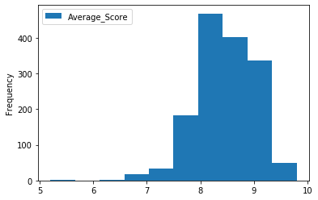

```python
dfplot = df[["Hotel_Name","Average_Score"]].drop_duplicates()
df2 = dfplot.plot.hist()
plt.show()
```

- *most ratings are between 7.6 and 9.2*

```python
plot_size = plt.rcParams["figure.figsize"]
print(plot_size[0])
print(plot_size[1])

plot_size[0] = 8
plot_size[1] = 6
plt.rcParams["figure.figsize"] = plot_size
```

```
6.0
4.0
```

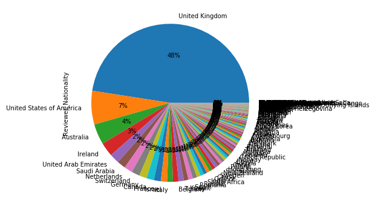

```python
df.Reviewer_Nationality.value_counts().plot(kind='pie', autopct='%1.0f%%')
```

### Cleaning The Data

When dealing with numerical data, data cleaning often involves removing null values and duplicate data, dealing with outliers, etc. With text data, there are some common data cleaning techniques, which are also known as text pre-processing techniques.

With text data, this cleaning process can go on forever. There's always an exception to every cleaning step. So, we're going to follow the MVP (minimum viable product) approach - start simple and iterate. We're going to execute just the common cleaning steps here and the rest can be done at a later point to improve our results.

Common data cleaning steps on all text:

Make text all lower case Remove punctuation Remove numerical values *Remove common non-sensical text (/n)*Tokenize text *Remove stop words

```python
### Checking Missing values in the Data Set and printing the Percentage for Missing Values for Each Columns ###

count = df.isnull().sum().sort_values(ascending=False)
percentage = ((df.isnull().sum()/len(df)*100)).sort_values(ascending=False)
missing_data = pd.concat([count, percentage], axis=1, keys = ['Count','Percentage'])
```

```python
# append the positive and negative text reviews
df["review"] =  df["Negative_Review"] +  df["Positive_Review"]
df["review"].head()
```

```
0     I am so angry that i made this post available...
1    No Negative No real complaints the hotel was g...
2     Rooms are nice but for elderly a bit difficul...
3     My room was dirty and I was afraid to walk ba...
4     You When I booked with your company on line y...
Name: review, dtype: object
```

#### Sample the data

```python
df = df.sample(frac = 0.2, replace = False, random_state=42)
```

```python
df["review"].tail()
```

```
359024     Breakfast is very good but next time can I pl...
4473      No Negative Excellent location near Kings Cros...
182260     That you had to log on to the wifi everyday f...
480114    No Negative Very good breakfast beautiful gard...
2601       Stayed in room 309 Club Room damp carpet by s...
Name: review, dtype: object
```

```python
# remove 'No Negative' or 'No Positive' from text
df['Content_Parsed_1'] = df['review'].str.replace("No Positive", '')
df['Content_Parsed_1'] = df['review'].str.replace("No Negative", '')
df['Content_Parsed_1'].tail()
```

```
359024     Breakfast is very good but next time can I pl...
4473       Excellent location near Kings Cross St Pancra...
182260     That you had to log on to the wifi everyday f...
480114     Very good breakfast beautiful garden and terr...
2601       Stayed in room 309 Club Room damp carpet by s...
Name: Content_Parsed_1, dtype: object
```

```python
# Apply a first round of text cleaning techniques
#1. Text cleaning and preparation Removing new line and
# \r and \n
df['Content_Parsed_1'] = df['Content_Parsed_1'].str.replace("\r", " ")
df['Content_Parsed_1'] = df['Content_Parsed_1'].str.replace("\n", " ")
df['Content_Parsed_1'] = df['Content_Parsed_1'].str.replace("    ", " ")
```

```python
# " when quoting text
df['Content_Parsed_1'] = df['Content_Parsed_1'].str.replace('"', '')
```

```python
# Lowercasing the text
df['Content_Parsed_2'] = df['Content_Parsed_1'].str.lower()
df['Content_Parsed_2'].tail()
```

```
359024     breakfast is very good but next time can i pl...
4473       excellent location near kings cross st pancra...
182260     that you had to log on to the wifi everyday f...
480114     very good breakfast beautiful garden and terr...
2601       stayed in room 309 club room damp carpet by s...
Name: Content_Parsed_2, dtype: object
```

```python
punctuation_signs = list("?:!.,;")
df['Content_Parsed_3'] = df['Content_Parsed_2']

for punct_sign in punctuation_signs:
    df['Content_Parsed_3'] = df['Content_Parsed_3'].str.replace(punct_sign, '')
```

```python
df['Content_Parsed_4'] = df['Content_Parsed_3'].str.replace("'s", "")
df['Content_Parsed_4'].tail()
```

```
359024     breakfast is very good but next time can i pl...
4473       excellent location near kings cross st pancra...
182260     that you had to log on to the wifi everyday f...
480114     very good breakfast beautiful garden and terr...
2601       stayed in room 309 club room damp carpet by s...
Name: Content_Parsed_4, dtype: object
```

```python
##Stop Words# Downloading the stop words list
nltk.download('stopwords')
```

```
True
```

```python
# Loading the stop words in english
stop_words = list(stopwords.words('english'))
```

```python
stop_words[0:10]
```

```
['i', 'me', 'my', 'myself', 'we', 'our', 'ours', 'ourselves', 'you', "you're"]
```

```python
df['Content_Parsed_5'] = df['Content_Parsed_4']

for stop_word in stop_words:

    regex_stopword = r"\b" + stop_word + r"\b"
    df['Content_Parsed_5'] = df['Content_Parsed_5'].str.replace(regex_stopword, '')
```

```python
df.tail()
```

|  | Hotel_Address | Additional_Number_of_Scoring | Review_Date | Average_Score | Hotel_Name | Reviewer_Nationality | Negative_Review | Review_Total_Negative_Word_Counts | Total_Number_of_Reviews | Positive_Review | ... | Tags | days_since_review | lat | lng | review | Content_Parsed_1 | Content_Parsed_2 | Content_Parsed_3 | Content_Parsed_4 | Content_Parsed_5 |
| --- | --- | --- | --- | --- | --- | --- | --- | --- | --- | --- | --- | --- | --- | --- | --- | --- | --- | --- | --- | --- | --- |
| 359024 | Kirchengasse 41 07 Neubau 1070 Vienna Austria | 69 | 8/18/2016 | 9.3 | Small Luxury Hotel Altstadt Vienna | Netherlands | Breakfast is very good but next time can I pl... | 17 | 664 | Great location great atmosphere great staff g... | ... | [' Leisure trip ', ' Family with young childre... | 350 day | 48.204776 | 16.351252 | Breakfast is very good but next time can I pl... | Breakfast is very good but next time can I pl... | breakfast is very good but next time can i pl... | breakfast is very good but next time can i pl... | breakfast is very good but next time can i pl... | breakfast good next time please freshly... |
| 4473 | 1 8 Russell Square Camden London WC1B 5BE Unit... | 724 | 8/17/2015 | 8.0 | The Principal London | United Kingdom | No Negative | 0 | 3150 | Excellent location near Kings Cross St Pancra... | ... | [' Leisure trip ', ' Family with young childre... | 717 day | 51.522622 | -0.125160 | No Negative Excellent location near Kings Cros... | Excellent location near Kings Cross St Pancra... | excellent location near kings cross st pancra... | excellent location near kings cross st pancra... | excellent location near kings cross st pancra... | excellent location near kings cross st pancra... |
| 182260 | 407 Goldhawk Rd Chiswick London W6 0SA United ... | 256 | 1/24/2017 | 7.8 | Chiswick Rooms | United Kingdom | That you had to log on to the wifi everyday f... | 17 | 882 | The reception staff was extremely hospitable ... | ... | [' Business trip ', ' Couple ', ' Compact Doub... | 191 day | 51.493741 | -0.244896 | That you had to log on to the wifi everyday f... | That you had to log on to the wifi everyday f... | that you had to log on to the wifi everyday f... | that you had to log on to the wifi everyday f... | that you had to log on to the wifi everyday f... | log wifi everyday fill username pas... |
| 480114 | Via Lazzaro Palazzi 18 Central Station 20124 M... | 64 | 3/15/2016 | 8.5 | Hotel Sanpi Milano | Romania | No Negative | 0 | 904 | Very good breakfast beautiful garden and terr... | ... | [' Leisure trip ', ' Group ', ' Double or Twin... | 506 day | 45.477762 | 9.203169 | No Negative Very good breakfast beautiful gard... | Very good breakfast beautiful garden and terr... | very good breakfast beautiful garden and terr... | very good breakfast beautiful garden and terr... | very good breakfast beautiful garden and terr... | good breakfast beautiful garden terrace |
| 2601 | 1 3 Queens Garden Westminster Borough London W... | 1058 | 2/22/2016 | 7.7 | The Park Grand London Paddington | United Kingdom | Stayed in room 309 Club Room damp carpet by s... | 19 | 4380 | Friendly staff Good location and facilities g... | ... | [' Business trip ', ' Solo traveler ', ' Club ... | 528 day | 51.514218 | -0.180903 | Stayed in room 309 Club Room damp carpet by s... | Stayed in room 309 Club Room damp carpet by s... | stayed in room 309 club room damp carpet by s... | stayed in room 309 club room damp carpet by s... | stayed in room 309 club room damp carpet by s... | stayed room 309 club room damp carpet showe... |

5 rows × 23 columns

```python
df["review_clean"] = df['Content_Parsed_5']
df["review_clean"].tail()
```

```
359024     breakfast   good  next time   please  freshly...
4473       excellent location near kings cross st pancra...
182260         log    wifi everyday fill   username  pas...
480114            good breakfast beautiful garden  terrace
2601       stayed  room 309 club room damp carpet  showe...
Name: review_clean, dtype: object
```

```python
# Downloading punkt and wordnet from NLTK
nltk.download('punkt')
print("------------------------------------------------------------")
nltk.download('wordnet')
```

```
True
```

```python
# # Apply a second round of cleaning
# return the wordnet object value corresponding to the POS tag
from nltk.corpus import wordnet

def get_wordnet_pos(pos_tag):
    if pos_tag.startswith('J'):
        return wordnet.ADJ
    elif pos_tag.startswith('V'):
        return wordnet.VERB
    elif pos_tag.startswith('N'):
        return wordnet.NOUN
    elif pos_tag.startswith('R'):
        return wordnet.ADV
    else:
        return wordnet.NOUN

import string
from nltk import pos_tag
from nltk.corpus import stopwords
from nltk.tokenize import WhitespaceTokenizer
from nltk.stem import WordNetLemmatizer

def clean_text(text):
    # lower text
    text = text.lower()
    # tokenize text and remove puncutation
    text = [word.strip(string.punctuation) for word in text.split(" ")]
    # remove words that contain numbers
    text = [word for word in text if not any(c.isdigit() for c in word)]
    # remove stop words
    stop = stopwords.words('english')
    text = [x for x in text if x not in stop]
    # remove empty tokens
    text = [t for t in text if len(t) > 0]
    # pos tag text
    pos_tags = pos_tag(text)
    # lemmatize text
    text = [WordNetLemmatizer().lemmatize(t[0], get_wordnet_pos(t[1])) for t in pos_tags]
    # remove words with only one letter
    text = [t for t in text if len(t) > 1]
    # join all
    text = " ".join(text)
    return(text)

# clean text data
df["reviews"] = df["review_clean"].apply(lambda x: clean_text(x))
```

```python
df.tail()
```

|  | Hotel_Address | Additional_Number_of_Scoring | Review_Date | Average_Score | Hotel_Name | Reviewer_Nationality | Negative_Review | Review_Total_Negative_Word_Counts | Total_Number_of_Reviews | Positive_Review | ... | lat | lng | review | Content_Parsed_1 | Content_Parsed_2 | Content_Parsed_3 | Content_Parsed_4 | Content_Parsed_5 | review_clean | reviews |
| --- | --- | --- | --- | --- | --- | --- | --- | --- | --- | --- | --- | --- | --- | --- | --- | --- | --- | --- | --- | --- | --- |
| 359024 | Kirchengasse 41 07 Neubau 1070 Vienna Austria | 69 | 8/18/2016 | 9.3 | Small Luxury Hotel Altstadt Vienna | Netherlands | Breakfast is very good but next time can I pl... | 17 | 664 | Great location great atmosphere great staff g... | ... | 48.204776 | 16.351252 | Breakfast is very good but next time can I pl... | Breakfast is very good but next time can I pl... | breakfast is very good but next time can i pl... | breakfast is very good but next time can i pl... | breakfast is very good but next time can i pl... | breakfast good next time please freshly... | breakfast good next time please freshly... | breakfast good next time please freshly squeez... |
| 4473 | 1 8 Russell Square Camden London WC1B 5BE Unit... | 724 | 8/17/2015 | 8.0 | The Principal London | United Kingdom | No Negative | 0 | 3150 | Excellent location near Kings Cross St Pancra... | ... | 51.522622 | -0.125160 | No Negative Excellent location near Kings Cros... | Excellent location near Kings Cross St Pancra... | excellent location near kings cross st pancra... | excellent location near kings cross st pancra... | excellent location near kings cross st pancra... | excellent location near kings cross st pancra... | excellent location near kings cross st pancra... | excellent location near king cross st pancras ... |
| 182260 | 407 Goldhawk Rd Chiswick London W6 0SA United ... | 256 | 1/24/2017 | 7.8 | Chiswick Rooms | United Kingdom | That you had to log on to the wifi everyday f... | 17 | 882 | The reception staff was extremely hospitable ... | ... | 51.493741 | -0.244896 | That you had to log on to the wifi everyday f... | That you had to log on to the wifi everyday f... | that you had to log on to the wifi everyday f... | that you had to log on to the wifi everyday f... | that you had to log on to the wifi everyday f... | log wifi everyday fill username pas... | log wifi everyday fill username pas... | log wifi everyday fill username password recep... |
| 480114 | Via Lazzaro Palazzi 18 Central Station 20124 M... | 64 | 3/15/2016 | 8.5 | Hotel Sanpi Milano | Romania | No Negative | 0 | 904 | Very good breakfast beautiful garden and terr... | ... | 45.477762 | 9.203169 | No Negative Very good breakfast beautiful gard... | Very good breakfast beautiful garden and terr... | very good breakfast beautiful garden and terr... | very good breakfast beautiful garden and terr... | very good breakfast beautiful garden and terr... | good breakfast beautiful garden terrace | good breakfast beautiful garden terrace | good breakfast beautiful garden terrace |
| 2601 | 1 3 Queens Garden Westminster Borough London W... | 1058 | 2/22/2016 | 7.7 | The Park Grand London Paddington | United Kingdom | Stayed in room 309 Club Room damp carpet by s... | 19 | 4380 | Friendly staff Good location and facilities g... | ... | 51.514218 | -0.180903 | Stayed in room 309 Club Room damp carpet by s... | Stayed in room 309 Club Room damp carpet by s... | stayed in room 309 club room damp carpet by s... | stayed in room 309 club room damp carpet by s... | stayed in room 309 club room damp carpet by s... | stayed room 309 club room damp carpet showe... | stayed room 309 club room damp carpet showe... | stayed room club room damp carpet shower room ... |

5 rows × 25 columns

```python
# add number of characters column
df["nb_chars"] = df["reviews"].apply(lambda x: len(x))

# add number of words column
df["nb_words"] = df["reviews"].apply(lambda x: len(x.split(" ")))
```

```python
df.info()
```

[output not shown]

[output cut: 19 more lines]

### Representing Text in Numeric Form

Statistical algorithms use mathematics to train machine learning models. However, mathematics only work with numbers. To make statistical algorithms work with text, we first have to convert text to numbers. To do so, three main approaches exist i.e. Bag of Words, TF-IDF and Word2Vec. We will USE the Word2Vec and TF-IDF scheme.

Each text can also be transformed into numerical vectors using the word vectors (Doc2Vec). Same texts will also have similar representations and that is why we can use those vectors as training features.

The module Gensim creates a numerical vector representation of every word in the corpus by using the contexts in which they appear (Word2Vec). We first have to train a Doc2Vec model by feeding in our text data. By applying this model on our reviews, we can get those representation vectors.

```python
# create doc2vec vector columns
from gensim.test.utils import common_texts
from gensim.models.doc2vec import Doc2Vec, TaggedDocument

documents = [TaggedDocument(doc, [i]) for i, doc in enumerate(df["reviews"].apply(lambda x: x.split(" ")))]

# train a Doc2Vec model with our text data
model = Doc2Vec(documents, vector_size=5, window=2, min_count=1, workers=4)

# transform each document into a vector data
doc2vec_df = df["reviews"].apply(lambda x: model.infer_vector(x.split(" "))).apply(pd.Series)
doc2vec_df.columns = ["doc2vec_vector_" + str(x) for x in doc2vec_df.columns]
df = pd.concat([df, doc2vec_df], axis=1)
```

```python
df.tail()
```

|  | Hotel_Address | Additional_Number_of_Scoring | Review_Date | Average_Score | Hotel_Name | Reviewer_Nationality | Negative_Review | Review_Total_Negative_Word_Counts | Total_Number_of_Reviews | Positive_Review | ... | Content_Parsed_5 | review_clean | reviews | nb_chars | nb_words | doc2vec_vector_0 | doc2vec_vector_1 | doc2vec_vector_2 | doc2vec_vector_3 | doc2vec_vector_4 |
| --- | --- | --- | --- | --- | --- | --- | --- | --- | --- | --- | --- | --- | --- | --- | --- | --- | --- | --- | --- | --- | --- |
| 359024 | Kirchengasse 41 07 Neubau 1070 Vienna Austria | 69 | 8/18/2016 | 9.3 | Small Luxury Hotel Altstadt Vienna | Netherlands | Breakfast is very good but next time can I pl... | 17 | 664 | Great location great atmosphere great staff g... | ... | breakfast good next time please freshly... | breakfast good next time please freshly... | breakfast good next time please freshly squeez... | 115 | 17 | -0.140978 | -0.033480 | 0.068217 | -0.097103 | -0.003559 |
| 4473 | 1 8 Russell Square Camden London WC1B 5BE Unit... | 724 | 8/17/2015 | 8.0 | The Principal London | United Kingdom | No Negative | 0 | 3150 | Excellent location near Kings Cross St Pancra... | ... | excellent location near kings cross st pancra... | excellent location near kings cross st pancra... | excellent location near king cross st pancras ... | 164 | 23 | 0.031300 | -0.039209 | 0.120941 | -0.128891 | 0.148315 |
| 182260 | 407 Goldhawk Rd Chiswick London W6 0SA United ... | 256 | 1/24/2017 | 7.8 | Chiswick Rooms | United Kingdom | That you had to log on to the wifi everyday f... | 17 | 882 | The reception staff was extremely hospitable ... | ... | log wifi everyday fill username pas... | log wifi everyday fill username pas... | log wifi everyday fill username password recep... | 224 | 30 | 0.145587 | 0.028723 | 0.223755 | -0.216921 | 0.091652 |
| 480114 | Via Lazzaro Palazzi 18 Central Station 20124 M... | 64 | 3/15/2016 | 8.5 | Hotel Sanpi Milano | Romania | No Negative | 0 | 904 | Very good breakfast beautiful garden and terr... | ... | good breakfast beautiful garden terrace | good breakfast beautiful garden terrace | good breakfast beautiful garden terrace | 39 | 5 | -0.078447 | 0.086737 | 0.042246 | -0.045560 | -0.039147 |
| 2601 | 1 3 Queens Garden Westminster Borough London W... | 1058 | 2/22/2016 | 7.7 | The Park Grand London Paddington | United Kingdom | Stayed in room 309 Club Room damp carpet by s... | 19 | 4380 | Friendly staff Good location and facilities g... | ... | stayed room 309 club room damp carpet showe... | stayed room 309 club room damp carpet showe... | stayed room club room damp carpet shower room ... | 170 | 27 | 0.077539 | -0.094901 | -0.117469 | -0.173995 | 0.057906 |

5 rows × 32 columns

#### TF-IDF using the Scikit-Learn Library

Python's Scikit-Learn library contains the TfidfVectorizer class that can be used to convert text features into TF-IDF feature vectors.

```python
# add tf-idfs columns
from sklearn.feature_extraction.text import TfidfVectorizer
tfidf = TfidfVectorizer(min_df = 10)
tfidf_result = tfidf.fit_transform(df['reviews']).toarray()
tfidf_df = pd.DataFrame(tfidf_result, columns = tfidf.get_feature_names())
tfidf_df.columns = ["word_" + str(x) for x in tfidf_df.columns]
tfidf_df.index = df.index
df = pd.concat([df, tfidf_df], axis=1)
```

```python
df['reviews']
```

```
235164    get glass wine sunday comfy bed good location ...
1550                                         super would go
436343    ask pay congestion charge firstly woman clue t...
162865    room could big perfect location spotless clean...
165722    room nice standard reception area hotel lovely...
                                ...
359024    breakfast good next time please freshly squeez...
4473      excellent location near king cross st pancras ...
182260    log wifi everyday fill username password recep...
480114              good breakfast beautiful garden terrace
2601      stayed room club room damp carpet shower room ...
Name: reviews, Length: 20630, dtype: object
```

#### Now let's print some wordclouds to have a glimpse at what kind of words apear in our reviews:

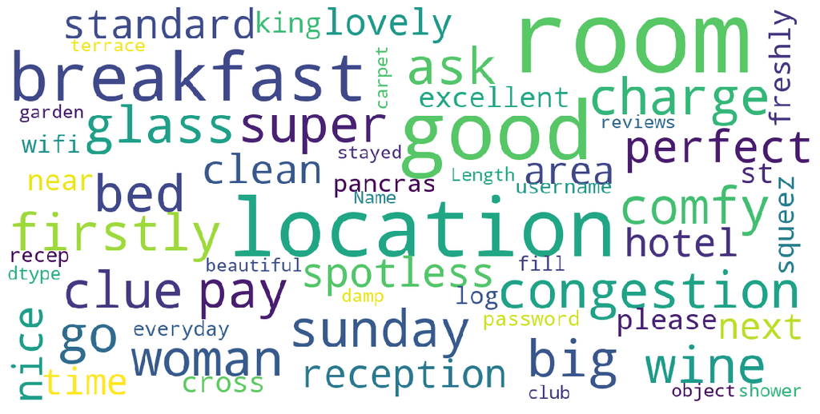

```python
# wordcloud function

from wordcloud import WordCloud
import matplotlib.pyplot as plt

def show_wordcloud(data, title = None):
    wordcloud = WordCloud(
        background_color = 'white',
        max_words = 500,
        max_font_size = 50,
        scale = 3,
        random_state = 42
    ).generate(str(data))

    fig = plt.figure(1, figsize = (20, 20))
    plt.axis('off')
    if title:
        fig.suptitle(title, fontsize = 20)
        fig.subplots_adjust(top = 2.3)

    plt.imshow(wordcloud)
    plt.show()

# print wordcloud
show_wordcloud(df["reviews"])
```

#### Most of the words are indeed related to the hotels: room, breakfast, location, etc. Some words are more related to the customer experience with the hotel stay: nice, big, comfy, lovely, perfect etc.

### Sentiment Analysis

At this point, all of the analysis we've done has been pretty generic - looking at wordcloud, plots, etc. These techniques could be applied to numeric data as well. Analyzing huge text data can be a daunting task not to mention time-consuming and expensive. Sentiment analysis, helps businesses make sense of all this unstructured text by automatically tagging it.

1. **TextBlob Module:** Linguistic researchers have labeled the sentiment of words based on their domain expertise. Sentiment of words can vary based on where it is in a sentence. The TextBlob module allows us to take advantage of these labels.
2. **Sentiment Labels:** Each word in a corpus is labeled in terms of polarity and subjectivity (there are more labels as well, but we're going to ignore them for now). A corpus' sentiment is the average of these.
   - **Polarity**: How positive or negative a word is. -1 is very negative. +1 is very positive.
   - **Subjectivity**: How subjective, or opinionated a word is. 0 is fact. +1 is very much an opinion.!

```python
df.info()
```

```
<class 'pandas.core.frame.DataFrame'>
Int64Index: 20630 entries, 235164 to 2601
Columns: 2443 entries, Hotel_Address to word_zone
dtypes: float32(5), float64(2415), int64(7), object(16)
memory usage: 384.3+ MB
```

```python
# Create quick lambda functions to find the polarity and subjectivity of each routine
# Terminal / Anaconda Navigator: conda install -c conda-forge textblob
from textblob import TextBlob

pol = lambda x: TextBlob(x).sentiment.polarity
sub = lambda x: TextBlob(x).sentiment.subjectivity

df['polarity'] = df['reviews'].apply(pol)
df['subjectivity'] = df['reviews'].apply(sub)
df.head()
```

|  | Hotel_Address | Additional_Number_of_Scoring | Review_Date | Average_Score | Hotel_Name | Reviewer_Nationality | Negative_Review | Review_Total_Negative_Word_Counts | Total_Number_of_Reviews | Positive_Review | ... | word_year | word_yes | word_yet | word_yoghurt | word_young | word_yummy | word_zero | word_zone | polarity | subjectivity |
| --- | --- | --- | --- | --- | --- | --- | --- | --- | --- | --- | --- | --- | --- | --- | --- | --- | --- | --- | --- | --- | --- |
| 235164 | 7 Gracechurch Street City of London London EC3... | 764 | 2/22/2016 | 8.2 | Club Quarters Hotel Gracechurch | United Kingdom | I couldn t get a glass of wine at 10 15 on a ... | 16 | 2996 | Comfy beds good location pleasant staff Great... | ... | 0.0 | 0.0 | 0.0 | 0.0 | 0.0 | 0.0 | 0.0 | 0.0 | 0.658333 | 0.779167 |
| 1550 | 1 2 Serjeant s Inn Fleet Street City of London... | 639 | 10/24/2016 | 9.2 | Apex Temple Court Hotel | United Kingdom | No Negative | 0 | 2619 | Super been before would go again | ... | 0.0 | 0.0 | 0.0 | 0.0 | 0.0 | 0.0 | 0.0 | 0.0 | 0.333333 | 0.666667 |
| 436343 | Royal Victoria Dock Western Gateway Newham Lon... | 879 | 6/28/2016 | 8.8 | Crowne Plaza London Docklands | United Kingdom | When I asked how to pay for the congestion ch... | 47 | 2768 | No Positive | ... | 0.0 | 0.0 | 0.0 | 0.0 | 0.0 | 0.0 | 0.0 | 0.0 | 0.119318 | 0.232197 |
| 162865 | 36 rue du Grenier Saint Lazare 3rd arr 75003 P... | 28 | 6/5/2016 | 8.8 | Hotel Georgette | United Kingdom | Room could be bigger | 6 | 307 | Perfect location Spotless cleaning Very nice ... | ... | 0.0 | 0.0 | 0.0 | 0.0 | 0.0 | 0.0 | 0.0 | 0.0 | 0.491667 | 0.700000 |
| 165722 | 372 Strand Westminster Borough London WC2R 0JJ... | 2288 | 11/30/2015 | 8.1 | Strand Palace Hotel | United Kingdom | the room were nice but not up to the same Sta... | 16 | 9568 | The hotel was lovely particularly reception b... | ... | 0.0 | 0.0 | 0.0 | 0.0 | 0.0 | 0.0 | 0.0 | 0.0 | 0.328333 | 0.516667 |

5 rows × 2445 columns

```python
df2 = df[['polarity', 'subjectivity']]
df2.head()
```

|  | polarity | subjectivity |
| --- | --- | --- |
| 235164 | 0.658333 | 0.779167 |
| 1550 | 0.333333 | 0.666667 |
| 436343 | 0.119318 | 0.232197 |
| 162865 | 0.491667 | 0.700000 |
| 165722 | 0.328333 | 0.516667 |

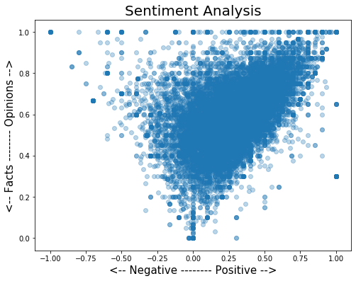

```python
import numpy as np
import matplotlib.pyplot as plt



N = 50
x = df2['polarity']
y = df2['subjectivity']

plt.scatter(x, y,alpha=0.3)
plt.title('Sentiment Analysis', fontsize=20)
plt.xlabel('<-- Negative -------- Positive -->', fontsize=15)
plt.ylabel('<-- Facts -------- Opinions -->', fontsize=15)
plt.show()
```

#### Though reviewer rating is a good reference, getting the sentiments from the actual review itself can make more sense on what areas to focus and prioritize

```python
df.head()
```

|  | Hotel_Address | Additional_Number_of_Scoring | Review_Date | Average_Score | Hotel_Name | Reviewer_Nationality | Negative_Review | Review_Total_Negative_Word_Counts | Total_Number_of_Reviews | Positive_Review | ... | word_year | word_yes | word_yet | word_yoghurt | word_young | word_yummy | word_zero | word_zone | polarity | subjectivity |
| --- | --- | --- | --- | --- | --- | --- | --- | --- | --- | --- | --- | --- | --- | --- | --- | --- | --- | --- | --- | --- | --- |
| 235164 | 7 Gracechurch Street City of London London EC3... | 764 | 2/22/2016 | 8.2 | Club Quarters Hotel Gracechurch | United Kingdom | I couldn t get a glass of wine at 10 15 on a ... | 16 | 2996 | Comfy beds good location pleasant staff Great... | ... | 0.0 | 0.0 | 0.0 | 0.0 | 0.0 | 0.0 | 0.0 | 0.0 | 0.658333 | 0.779167 |
| 1550 | 1 2 Serjeant s Inn Fleet Street City of London... | 639 | 10/24/2016 | 9.2 | Apex Temple Court Hotel | United Kingdom | No Negative | 0 | 2619 | Super been before would go again | ... | 0.0 | 0.0 | 0.0 | 0.0 | 0.0 | 0.0 | 0.0 | 0.0 | 0.333333 | 0.666667 |
| 436343 | Royal Victoria Dock Western Gateway Newham Lon... | 879 | 6/28/2016 | 8.8 | Crowne Plaza London Docklands | United Kingdom | When I asked how to pay for the congestion ch... | 47 | 2768 | No Positive | ... | 0.0 | 0.0 | 0.0 | 0.0 | 0.0 | 0.0 | 0.0 | 0.0 | 0.119318 | 0.232197 |
| 162865 | 36 rue du Grenier Saint Lazare 3rd arr 75003 P... | 28 | 6/5/2016 | 8.8 | Hotel Georgette | United Kingdom | Room could be bigger | 6 | 307 | Perfect location Spotless cleaning Very nice ... | ... | 0.0 | 0.0 | 0.0 | 0.0 | 0.0 | 0.0 | 0.0 | 0.0 | 0.491667 | 0.700000 |
| 165722 | 372 Strand Westminster Borough London WC2R 0JJ... | 2288 | 11/30/2015 | 8.1 | Strand Palace Hotel | United Kingdom | the room were nice but not up to the same Sta... | 16 | 9568 | The hotel was lovely particularly reception b... | ... | 0.0 | 0.0 | 0.0 | 0.0 | 0.0 | 0.0 | 0.0 | 0.0 | 0.328333 | 0.516667 |

5 rows × 2445 columns

[figure not shown]

```python
df_corr = df.corr()

# Get the colors for the graphic
colors = []
dim = df_corr.shape[0]
for i in range(dim):
    r = i * 1/dim
    colors.append((0.3,r,0.3))

# Transform each value in a positive value, because what interesses us
# isn't the direction of the correlation but the absolute correlation
df_corr["Reviewer_Score"].apply(lambda x: abs(x)).sort_values().plot.barh(color = colors)
plt.title("Correlation with Reviewer_Score", fontsize = 16)
plt.show()
```

```python
# Columns to use to train the models
# Only the columns with the highest correlation were chosen
cols = ['Review_Total_Negative_Word_Counts',
        'Total_Number_of_Reviews',
        'Average_Score',
        'Review_Total_Positive_Word_Counts']

X = df[cols].values
y = df["Reviewer_Score"].values
```

```python
import seaborn as sns
```

```python
# Use StandardScaler to scale the data
from sklearn.preprocessing import StandardScaler
scaler = StandardScaler()
X = scaler.fit_transform(X)
```

```python
from sklearn.model_selection import train_test_split
X_train, X_test, y_train, y_test = train_test_split(X, y, test_size=0.2, random_state=0)

from sklearn.metrics import mean_squared_error

def plot_res(y_test,pred, model = "LinearRegression"):
# Violinplots with the distribution of real scores and predicted scores

    MSRE = round((mean_squared_error(y_test,pred))**0.5,3)
    fig, axes = plt.subplots(nrows=1, ncols=2, figsize = (12,6))

    sns.violinplot(y_test, ax = axes[0])
    axes[0].set_title("Distribution of\n scores")
    axes[0].set_xlim(0,11)

    sns.violinplot(pred, ax = axes[1])
    title = f"Predictions of scores with {model}\nMSRE:{MSRE}"
    axes[1].set_title(title)
    axes[1].set_xlim(0,11)
    plt.show()
```

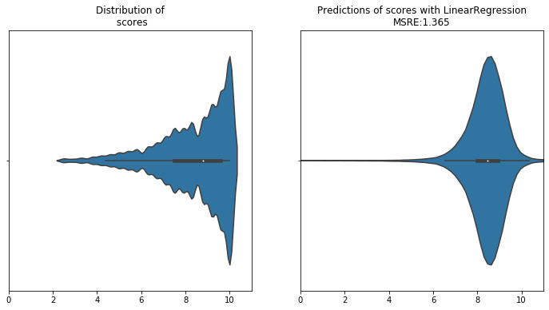

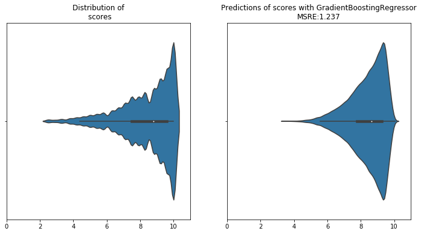

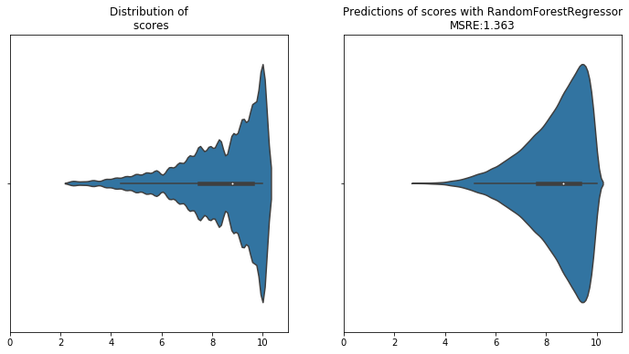

```python
# LinearRegression
from sklearn.linear_model import LinearRegression

model = LinearRegression()
model.fit(X_train, y_train)
pred = model.predict(X_test)
plot_res(y_test,pred, model = "LinearRegression")

# GradientBoostingRegressor
from sklearn.ensemble import GradientBoostingRegressor
model = GradientBoostingRegressor()
model.fit(X_train, y_train)
pred = model.predict(X_test)
plot_res(y_test,pred, model = "GradientBoostingRegressor")

# RandomForestRegressor
from sklearn.ensemble import RandomForestRegressor
model = RandomForestRegressor()
model.fit(X_train, y_train)
pred = model.predict(X_test)
plot_res(y_test,pred, model = "RandomForestRegressor")
```